# shiny tutorial 04 - Layouts

2020-03-29T23:50:39+09:00

## 공지

이번에 준비한 튜토리얼은 제 강의를 듣는 과거-현재-미래 수강생분들을 위해 준비한 자료이다. 많은 도움이 되기를 바란다

이번에 준비한 Tutorial 코로나 세계현황을 `Shiny Dashboard`로 만들어 가는 과정을 담았다.

## I. 이전 글 소개

처음 shiny를 접하거나 shiny의 전체 튜토리얼이 궁금한 사람들을 위해 이전 글을 소개한다. - [shiny tutorial 01 - get started](https://chloevan.github.io/r/shiny/tutorial_01/) - [shiny tutorial 02 - Shiny Structure](https://chloevan.github.io/r/shiny/tutorial_02/) - [shiny tutorial 03 - HTML content](https://chloevan.github.io/r/shiny/tutorial_03/)

## II. Layouts의 개요

이번 시간에는 `Shiny Layouts` 개요에 대한 간략적인 소개를 하려고 한다. 영어가 편하거나 중고급 개발자 분들은 [Application layout guide](https://shiny.rstudio.com/articles/layout-guide.html)를 참고하기를 바란다.

사실, 이 부분은 자세하게 다루기에는 부담이 존재한다. `Layouts`에 대한 디자인은 굉장히 주관적일 뿐더러, 처음부터 만들어가려면 그만큼 시간도 오래 걸리기 때문이다. 우리가 잊지말아야 하는 것 중의 하나는 `Data Scientist`는 `Web Developer`는 아니다. 기존의 `Web Developer`보다 대시보드를 시각적으로 더 잘 만들수는 없다. 그러나, 어떤 수집딘 데이터에서 어떤 `Insight`를 클라이언트에게 전달하지는 `Web Developer`보다는 더 나은 포지션에 있다.

따라서, `Layout`의 큰 개념만 잡는다면 다음부터는 `R`에서 제공하는 주요 `Dashboard` 패키지를 사용하는 것을 적극 권장한다.

## 예시 1. Sidebar Layout

이러한 `Layout`은 보통 화면 왼쪽에는 (단, Mobile 화면 위쪽) `input`에 관한 기능이 나온다면, 화면 오른쪽에는 `input`에 따라 결과값이 나타나는 `output`의 그래프, 표 등이 출력된다.

```
##
## Listening on http://127.0.0.1:6286
```

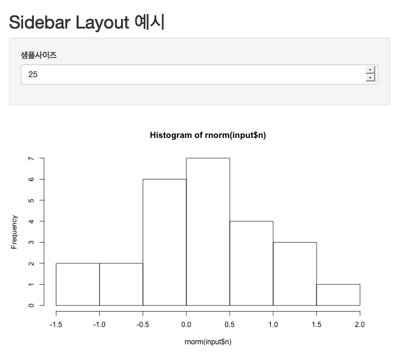

```r
# 패키지
library(shiny)

# ui 정의
ui <- fluidPage(
  titlePanel("Sidebar Layout 예시"), # 제목 Panel

  sidebarLayout(
    sidebarPanel(
      numericInput(
        inputId = "n", label = "샘플사이즈",
        value = 25
      )
    ),

    mainPanel(
      plotOutput(outputId = "hist")
    )
  )
)

# server 정의
# output will be displayed
server <- function(input, output) {
  output$hist <- renderPlot({
    hist(rnorm(input$n))
  })
}

# shinyApp 실행
shinyApp(ui = ui, server = server)
```

## 예시 2. Grid Layout

`sidebarLayout()`은 가장 낮은 수준의 grid layout을 제공하고 있는데, 본 예시에서는 조금 더 구체적으로 `Grid Layout`을 지정하도록 한다. 여기서 알아두어야 할 핵심 함수는 아래와 같다. - `fluidRow()`: 행과 관련이 있다. - `column()`: 열과 관련이 있다.

Column의 너비는 은 [Bootstrp 12-wide grid system](https://getbootstrap.com/docs/4.0/layout/grid/)에 기초하며, 하나의 `fluidRow()`안에는 12개의 `column()`이 존재한다. (다시한번 느끼지만, Shiny를 잘할려면 HTML/CSS/JS를 잘해야 한다!)

```
##
## Listening on http://127.0.0.1:4447
```

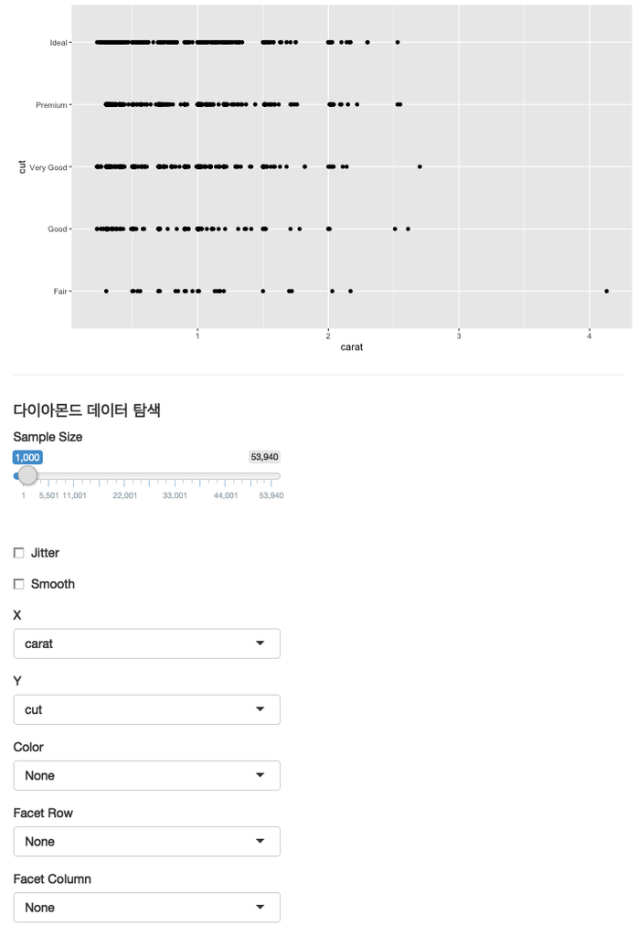

```r
library(shiny)
library(ggplot2)

dataset <- diamonds

ui <- fluidPage(

  title = "다이아몬드 데이터 탐색",

  plotOutput('plot'),

  hr(),

  fluidRow(
    column(3,
      h4("다이아몬드 데이터 탐색"),
      sliderInput('sampleSize', 'Sample Size',
                  min=1, max=nrow(dataset), value=min(1000, nrow(dataset)),
                  step=500, round=0),
      br(),
      checkboxInput('jitter', 'Jitter'),
      checkboxInput('smooth', 'Smooth')
    ),
    column(4, offset = 1,
      selectInput('x', 'X', names(dataset)),
      selectInput('y', 'Y', names(dataset), names(dataset)[[2]]),
      selectInput('color', 'Color', c('None', names(dataset)))
    ),
    column(4,
      selectInput('facet_row', 'Facet Row', c(None='.', names(dataset))),
      selectInput('facet_col', 'Facet Column', c(None='.', names(dataset)))
    )
  )
)

server <- function(input, output){

  dataset <- reactive({
    diamonds[sample(nrow(diamonds), input$sampleSize),]
  })

  output$plot <- renderPlot({

    p <- ggplot(dataset(), aes_string(x=input$x, y=input$y)) + geom_point()

    if (input$color != 'None')
      p <- p + aes_string(color=input$color)

    facets <- paste(input$facet_row, '~', input$facet_col)
    if (facets != '. ~ .')
      p <- p + facet_grid(facets)

    if (input$jitter)
      p <- p + geom_jitter()
    if (input$smooth)
      p <- p + geom_smooth()

    print(p)

  }, height=400, width = 700)
}

shinyApp(ui = ui, server = server)
```

## 예시 3. Navbar Pages

일반적인 웹사이트 메뉴 구성도와 큰 차이가 없다. 메뉴를 구성하는데, Top 메뉴와 Secondary Navigation까지 지원이 가능하다.

이 기능을 구현할 때는 사실상의 `Shiny Project` 단계로 진입하기 때문에, 이 때에는 메뉴 구성도와 같은 `웹사이트 개발 지식`이 수반되어야 한다.

```r
library(shiny)

ui <- navbarPage("My Application",
  tabPanel("Component 1"),
  tabPanel("Component 2"),
  navbarMenu("More",
    tabPanel("Sub-Component A"),
    tabPanel("Sub-Component B"))
)

server <- function(input, output) {

}

shinyApp(ui = ui, server = server)
```

```
##
## Listening on http://127.0.0.1:7782
```

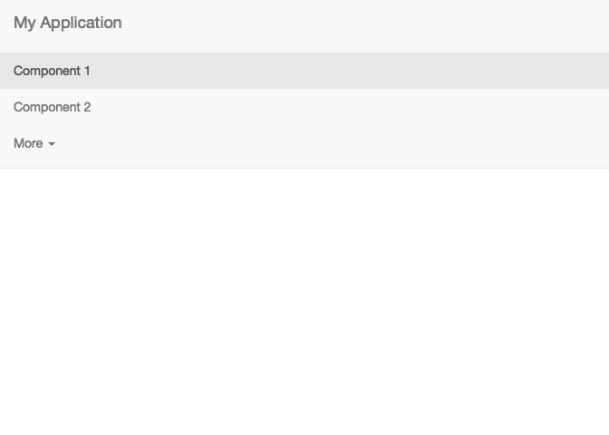

지금까지 `Layouts`의 기본 개요와 함께 주요 `Functions`에 대해 간단하게 학습하는 시간을 가졌다. 여기에서는 `Layouts`의 기본 개념만 알고 있으면 추후에 `Shiny` 대시보드 디자인을 할 때, 보다 쉽게 구현이 가능하다.

특히, Grid System에 대한 개념이 매우 중요하므로 [Application layout guide](https://shiny.rstudio.com/articles/layout-guide.html)에서 추가 학습을 진행하는 것을 권장한다.

## IV. Reference

Allaire. (2014, January 24). Application layout guide. Retrieved March 30, 2020, from https://shiny.rstudio.com/articles/layout-guide.html

Congratulation! You Mastered Layouts in Shiny